TESISQUARE

# Tesisquare Dataset Analysis

## A data science project by Porsche GTRR

We are the Porsche GTRR a team formed by Grosso Luca, Torterolo Francesco, Risso Beatrice e Robresco Simone

# Tesisquare Dataset Analysis Project

### Roles:

- **Graphics Designer:** Luca Grosso
- **Coders:** Simone Robresco, Francesco Torterolo, Beatrice Risso
- **Code reviewer:** Luca Grosso, Beatrice Risso
- **Notebook Redactor:** Beatrice Risso, Luca Grosso

## CSV Structure

- **SERVICETYPE:** type of service or vehicle used for the delivery
- **VEHICLETYPE:** type of vehicle
- **DEPARTURE_COUNTRY:** country of departure
- **DEPARTURE_ZIPCODE:** zipocde (CAP) of departure
- **ARRIVAL_COUNTRY:** country of arrival
- **ARRIVAL_ZIPCODE:** zipcode (CAP) of arrival

## Introduction

Simone Robresco, Francesco Torterolo, and Beatrice Risso developed the code for data analysis and visualization. Simone Robresco and Luca Grosso designed the types of charts used and the website. Beatrice Risso and Luca Grosso organized the notebook and customized the project presentation.

# Dataset Description

The dataset provides logistics data from a company that handles intercontinental shipments, including:

- Logistics details (e.g., mode of transport used, services utilized, shipping day and date).
- Travel-related information (e.g., departure and arrival countries, departure and arrival zip codes, distance in km).
- Information related to the transported products (e.g., net and gross weight, volume).

Understanding the data's structure and cleaning it is crucial before diving into the analysis.

# Exploratory Data Analysis (EDA)

## **Goals of the Analysis**

The main objective of this analysis is to understand the relationships between the characteristics of the shipments and the delivery times. Key areas of interest include:

- The difference in vehicles and services.
- The departure and arrival countries
- The shipping date.

### Importation of libraries and upload of the dataset

In this cell we are importing all the libraries that will be necessary for all the different snippets, and than upload the dataset via an xls file that we gained before using the API on the original dataset

```python
import pandas as pd
import numpy as np
import matplotlib.pyplot as plt
import time
import requests
from math import radians, sin, cos, sqrt, atan2
from sklearn.model_selection import train_test_split
from sklearn.ensemble import RandomForestClassifier
from sklearn.metrics import accuracy_score, classification_report, confusion_matrix
import seaborn as sns
import pandas as pd
import numpy as np
from sklearn.model_selection import train_test_split
from sklearn.ensemble import RandomForestClassifier
from sklearn.metrics import accuracy_score, classification_report
from sklearn.preprocessing import LabelEncoder
from datetime import datetime
```

```python
# Upload of the dataset
file_path = './delivery_data.xls'
data = pd.read_csv(file_path)
```

### Basic analysis of the features and values of the dataset

In the next three cells we analyzed the dataset to understand how to work on it, specially trying to understand how many NULL data for each feature we had

```python
# Shows the first rows of the dataset
print("First rows of the dataset:")
print(data.head())
```

```
First rows of the dataset:
   Unnamed: 0 SERVICETYPE VEHICLETYPE DEPARTURE_COUNTRY  DEPARTURE_ZIPCODE  \
0           1         NaN         NaN                IT            62010.0
1           2         NaN         NaN                IT            62010.0
2           3         NaN         NaN                IT            62010.0
3           4         NaN         NaN                IT            62010.0
4           5         NaN         NaN                IT            62010.0

  ARRIVAL_COUNTRY  ARRIVAL_ZIPCODE        SHIPPING_DATE  GROSS_WEIGHT_KG  \
0              IT            20121  2023-01-11 00:00:14             7.30
1              IT            15069  2023-01-11 00:00:14             1.70
2              IT            10036  2023-01-11 00:00:14             0.72
3              IT            70121  2023-01-11 00:00:14             0.86
4              IT            20090  2023-01-11 00:00:14             0.58

   NET_WEIGHT_KG  VOLUME_M3  DECLARED_DISTANCE_KM ACTUAL_DELIVERY_DATE  \
0           7.00        0.0                402.36  2022-11-16 00:00:14
1           1.40        0.0                390.04  2022-11-16 00:00:14
2           0.42        0.0                485.70  2022-11-17 00:00:14
3           0.56        0.0                385.81  2022-11-16 00:00:14
4           0.28        0.0                407.61  2022-11-16 00:00:14

   DELIVERY_TIME_HH  WDAY
0             -1344     2
1             -1344     2
2             -1320     2
3             -1344     2
4             -1344     2
```

```python
# Descriptive statistics
print("\nDescriptive statistics:")
data.describe()
```

```
Descriptive statistics:
```

|  | Unnamed: 0 | DEPARTURE_ZIPCODE | ARRIVAL_ZIPCODE | GROSS_WEIGHT_KG | NET_WEIGHT_KG | VOLUME_M3 | DECLARED_DISTANCE_KM | DELIVERY_TIME_HH | WDAY |
| --- | --- | --- | --- | --- | --- | --- | --- | --- | --- |
| count | 14554.000000 | 14548.000000 | 14554.000000 | 14554.000000 | 14554.000000 | 14554.000000 | 13425.000000 | 14554.000000 | 14554.000000 |
| mean | 7277.500000 | 53013.321694 | 41699.581352 | 9.744264 | 8.002172 | 0.188305 | 689.006913 | 75.783633 | 1.730177 |
| std | 4201.522244 | 22512.124864 | 30222.758997 | 34.946037 | 31.718243 | 0.983377 | 1423.294836 | 79.110044 | 1.507748 |
| min | 1.000000 | 12.000000 | 10.000000 | 0.020000 | 0.000000 | 0.000000 | 0.640000 | -1344.000000 | 0.000000 |
| 25% | 3639.250000 | 56122.750000 | 17031.000000 | 1.000000 | 0.000000 | 0.010000 | 233.770000 | 37.000000 | 0.000000 |
| 50% | 7277.500000 | 63076.000000 | 35042.000000 | 1.370000 | 0.000000 | 0.010000 | 407.910000 | 71.000000 | 1.000000 |
| 75% | 10915.750000 | 63076.000000 | 66020.000000 | 3.160000 | 2.280000 | 0.110000 | 509.410000 | 108.000000 | 3.000000 |
| max | 14554.000000 | 99208.000000 | 99518.000000 | 1039.820000 | 948.840000 | 105.000000 | 13012.860000 | 1920.000000 | 6.000000 |

```python
print("Dataset size:", data.shape)  # Dataset's dimension
data.info()  # General information about data types and counting NON-null values

# We calculate the number of missing values for each column
missing_values = data.isnull().sum()

# Printing of missing data in different columns
print("Columns with missing data")
missing_values[missing_values > 0]  # We only show columns with missing values


# List of specific columns to analyze
colonne_selezionate = [
    'SERVICETYPE',
    'VEHICLETYPE',
    'DEPARTURE_COUNTRY',
    'ARRIVAL_COUNTRY',
    'GROSS_WEIGHT_KG',
    'NET_WEIGHT_KG',
    'VOLUME_M3',
    'DECLARED_DISTANCE_KM',
    'DELIVERY_TIME_HH',
    'WDAY'
]

# Displaying the count for each selected column
for column in colonne_selezionate:
    print(f"\nCount values for the column '{column}':")
    print(data[column].value_counts())
    print("-" * 50)  # Separation line for better readability
```

```
Dataset size: (14554, 15)
<class 'pandas.core.frame.DataFrame'>
RangeIndex: 14554 entries, 0 to 14553
Data columns (total 15 columns):
 #   Column                Non-Null Count  Dtype
---  ------                --------------  -----
 0   Unnamed: 0            14554 non-null  int64
 1   SERVICETYPE           14340 non-null  object
 2   VEHICLETYPE           14331 non-null  object
 3   DEPARTURE_COUNTRY     14554 non-null  object
 4   DEPARTURE_ZIPCODE     14548 non-null  float64
 5   ARRIVAL_COUNTRY       14554 non-null  object
 6   ARRIVAL_ZIPCODE       14554 non-null  int64
 7   SHIPPING_DATE         14554 non-null  object
 8   GROSS_WEIGHT_KG       14554 non-null  float64
 9   NET_WEIGHT_KG         14554 non-null  float64
 10  VOLUME_M3             14554 non-null  float64
 11  DECLARED_DISTANCE_KM  13425 non-null  float64
 12  ACTUAL_DELIVERY_DATE  14554 non-null  object
 13  DELIVERY_TIME_HH      14554 non-null  int64
 14  WDAY                  14554 non-null  int64
dtypes: float64(5), int64(4), object(6)
memory usage: 1.7+ MB
Columns with missing data

Count values for the column 'SERVICETYPE':
SERVICETYPE
E-commerce                7982
Corriere espresso         2982
Via gomma                 1863
E-commerce Resi           1503
Corriere espresso resi      10
Name: count, dtype: int64
--------------------------------------------------

Count values for the column 'VEHICLETYPE':
VEHICLETYPE
Standard            8161
Express             3833
Ground              1966
```

[output cut: 99 more lines]

```
464       1
Name: count, Length: 310, dtype: int64
--------------------------------------------------

Count values for the column 'WDAY':
WDAY
0    3895
1    3630
2    2476
3    2225
4    1884
5     276
6     168
Name: count, dtype: int64
--------------------------------------------------
```

## Calculate the distance

This code uses an extern API called Nominatim to calculate the distances between the zip code

```python
def get_coordinates(postal_code, country):
    """
    Ottiene le coordinate geografiche di un codice postale per IT o US
    """
    if country not in ['IT', 'US']:
        raise ValueError(f"Paese non supportato: {country}")

    # Costruisce la query appropriata per il paese
    if country == 'IT':
        query = f"{postal_code}, Italy"
    else:
        query = f"{postal_code}, United States"

    url = "https://nominatim.openstreetmap.org/search"
    params = {
        "q": query,
        "format": "json",
        "limit": 1,
        "countrycodes": country.lower()
    }
    headers = {
        "User-Agent": "DistanceCalculator/1.0"
    }

    try:
        response = requests.get(url, params=params, headers=headers)
        response.raise_for_status()
        data = response.json()

        if not data:
            raise ValueError(f"Codice postale non trovato: {postal_code} in {country}")

        # Rispetta il rate limiting di Nominatim
        time.sleep(1)

        return {
            "lat": float(data[0]["lat"]),
            "lon": float(data[0]["lon"])
        }
    except requests.exceptions.RequestException as e:
        raise Exception(f"Errore nella richiesta API: {str(e)}")

def calculate_distance(coord1, coord2):
    """
    Calcola la distanza in kilometri tra due punti usando la formula di Haversine
    """
    R = 6371  # Raggio della Terra in km

    lat1, lon1 = radians(coord1["lat"]), radians(coord1["lon"])
    lat2, lon2 = radians(coord2["lat"]), radians(coord2["lon"])

    dlat = lat2 - lat1
    dlon = lon2 - lon1

    a = sin(dlat/2)**2 + cos(lat1) * cos(lat2) * sin(dlon/2)**2
    c = 2 * atan2(sqrt(a), sqrt(1-a))
    distance = R * c

    return distance

def process_csv(file_path):
    """
    Legge il CSV e aggiorna le distanze mancanti nella colonna DECLARED_DISTANCE_KM
    per spedizioni IT-IT, US-US, IT-US e US-IT
    """
    try:
        # Legge il CSV
        df = pd.read_csv(file_path)

        # Se non esiste la colonna DECLARED_DISTANCE_KM, la crea
        if 'DECLARED_DISTANCE_KM' not in df.columns:
            df['DECLARED_DISTANCE_KM'] = np.nan

        # Filtra le spedizioni IT e US
        mask = (
            ((df['DEPARTURE_COUNTRY'].isin(['IT', 'US'])) &
             (df['ARRIVAL_COUNTRY'].isin(['IT', 'US'])))
        )
        valid_rows = df[mask].index

        if len(valid_rows) == 0:
            raise ValueError("Nessuna spedizione IT/US trovata nel CSV")

        # Statistiche iniziali
        stats = {
            'IT-IT': len(df[(df['DEPARTURE_COUNTRY'] == 'IT') & (df['ARRIVAL_COUNTRY'] == 'IT')]),
            'US-US': len(df[(df['DEPARTURE_COUNTRY'] == 'US') & (df['ARRIVAL_COUNTRY'] == 'US')]),
            'IT-US': len(df[(df['DEPARTURE_COUNTRY'] == 'IT') & (df['ARRIVAL_COUNTRY'] == 'US')]),
            'US-IT': len(df[(df['DEPARTURE_COUNTRY'] == 'US') & (df['ARRIVAL_COUNTRY'] == 'IT')])
        }

        print("Spedizioni trovate:")
        for route, count in stats.items():
            print(f"{route}: {count}")

        # Conta quante distanze devono essere calcolate
        missing_distances = df.loc[valid_rows, 'DECLARED_DISTANCE_KM'].isna().sum()
        print(f"\nDistanze da calcolare: {missing_distances}")

        # Elabora le righe con distanza mancante
        rows_processed = 0
        for idx in valid_rows:
            # Salta se la distanza è già presente
            if pd.notna(df.at[idx, 'DECLARED_DISTANCE_KM']):
                continue

            try:
                departure_code = str(df.at[idx, 'DEPARTURE_ZIPCODE'])
                arrival_code = str(df.at[idx, 'ARRIVAL_ZIPCODE'])
                departure_country = df.at[idx, 'DEPARTURE_COUNTRY']
                arrival_country = df.at[idx, 'ARRIVAL_COUNTRY']

                # Ottiene le coordinate
                coord1 = get_coordinates(departure_code, departure_country)
                coord2 = get_coordinates(arrival_code, arrival_country)

                # Calcola la distanza
                distance = calculate_distance(coord1, coord2)
                df.at[idx, 'DECLARED_DISTANCE_KM'] = round(distance, 2)

                rows_processed += 1
                print(f"Elaborata riga {idx + 1}: {departure_code}({departure_country}) -> "
                      f"{arrival_code}({arrival_country}) = {distance:.2f} km ({rows_processed}/{missing_distances})")

                # Salva periodicamente ogni 10 righe elaborate
                if rows_processed % 10 == 0:
                    df.to_csv(file_path, index=False)
                    print(f"Salvaggio intermedio effettuato dopo {rows_processed} righe")

            except Exception as e:
                print(f"Errore nella riga {idx + 1}: {str(e)}")
                continue

        # Salvataggio finale
        df.to_csv(file_path, index=False)
        print(f"\nFile aggiornato salvato in: {file_path}")

        # Mostra statistiche finali per ogni tipo di percorso
        print("\nStatistiche delle distanze per tipo di percorso:")
        for dep_country in ['IT', 'US']:
            for arr_country in ['IT', 'US']:
                route_mask = (df['DEPARTURE_COUNTRY'] == dep_country) & (df['ARRIVAL_COUNTRY'] == arr_country)
                route_distances = df[route_mask]['DECLARED_DISTANCE_KM'].dropna()

                if not route_distances.empty:
                    print(f"\n{dep_country}-{arr_country}:")
                    print(f"Numero spedizioni: {len(route_distances)}")
                    print(f"Distanza media: {route_distances.mean():.2f} km")
                    print(f"Distanza massima: {route_distances.max():.2f} km")
                    print(f"Distanza minima: {route_distances.min():.2f} km")

        return df

    except Exception as e:
        raise Exception(f"Errore nell'elaborazione del CSV: {str(e)}")

# Esempio di utilizzo
if __name__ == "__main__":
    try:
        input_file = input("Inserisci il percorso del file CSV da elaborare: ")
        results = process_csv(input_file)

    except Exception as e:
        print(f"Errore: {str(e)}")
```

### Count of shippings arrival and departure

Than we tried to find out how many deliveries we had from various combination of start point and arrival point:

- from US to Everywhere
- from US to Everywhere (listed based on the country of arrival)
- from US to US
- from US to IT
- from IT to Everywhere
- from IT to Everywhere (listed based on the country of arrival)
- from IT to US
- from IT to IT

```python
# Count shipments from the United States (US)
us_shipments_count = data[data['DEPARTURE_COUNTRY'] == 'US'].shape[0]
print(f"\nNumber of shipments from US: {us_shipments_count}")


# Shipment count by country of arrival, only for those departing from the US
arrival_counts_us = data[data['DEPARTURE_COUNTRY'] == 'US']['ARRIVAL_COUNTRY'].value_counts()
print("\nShipment count by country of arrival (shipments from US only):")
print(arrival_counts_us)


# Total shipments from US to IT
us_to_it_count = data[(data['DEPARTURE_COUNTRY'] == 'US') & (data['ARRIVAL_COUNTRY'] == 'IT')].shape[0]
print(f"Number of shipments from US to IT: {us_to_it_count}")


# Total shipments from US to US
us_to_us_count = data[(data['DEPARTURE_COUNTRY'] == 'US') & (data['ARRIVAL_COUNTRY'] == 'US')].shape[0]
print(f"Number of shipments from US to US: {us_to_us_count}")


# Count shipments from Italy (IT)
it_shipments_count = data[data['DEPARTURE_COUNTRY'] == 'IT'].shape[0]
print(f"\nNumber of shipments from IT: {it_shipments_count}")


# Shipment count by country of arrival, only for those departing from IT
arrival_counts_it = data[data['DEPARTURE_COUNTRY'] == 'IT']['ARRIVAL_COUNTRY'].value_counts()
print("\nShipment count by country of arrival (departments from IT only):")
print(arrival_counts_it)


# Total shipments from IT to US
it_to_us_count = data[(data['DEPARTURE_COUNTRY'] == 'IT') & (data['ARRIVAL_COUNTRY'] == 'US')].shape[0]
print(f"Number of shipments from IT to US: {it_to_us_count}")


# Total shipments from IT to IT
it_to_it_count = data[(data['DEPARTURE_COUNTRY'] == 'IT') & (data['ARRIVAL_COUNTRY'] == 'IT')].shape[0]
print(f"Number of shipments from IT to IT: {it_to_it_count}")
```

```
Number of shipments from US: 2225

Shipment count by country of arrival (shipments from US only):
ARRIVAL_COUNTRY
US    2225
Name: count, dtype: int64
Number of shipments from US to IT: 0
Number of shipments from US to US: 2225

Number of shipments from IT: 12329

Shipment count by country of arrival (departments from IT only):
ARRIVAL_COUNTRY
IT    11755
US      574
Name: count, dtype: int64
Number of shipments from IT to US: 574
Number of shipments from IT to IT: 11755
```

```python
# Filter rows without null values
data_no_nulls = data.dropna()

# Save the new DataFrame to a CSV file
output_file_path = './delivery_clean.csv'
data_no_nulls.to_csv(output_file_path, index=False)

print(f"New CSV created with rows without null values: {output_file_path}")
```

```
New CSV created with rows without null values: ./delivery_clean.csv
```

```python
# Upload the xls file
file_path = 'Definitivo.xls'  # Sostituisci con il percorso del tuo file CSV
df = pd.read_csv(file_path)

# Check negative values in the DELIVERY_TIME_HH column
mask = df['DELIVERY_TIME_HH'] < 0

# Reverse the values of the columns SHIPPING_DATE and ACTUAL_DELIVERY_DATE for rows with negative values
df.loc[mask, ['SHIPPING_DATE', 'ACTUAL_DELIVERY_DATE']] = df.loc[mask, ['ACTUAL_DELIVERY_DATE', 'SHIPPING_DATE']].values

# Save the modified DataFrame to a new CSV file
output_file_path = 'Definitivo1.csv'  # Replace with the desired path for the output file
df.to_csv(output_file_path, index=False)

print("Edit completed and file saved as:", output_file_path)
```

```
Edit completed and file saved as: Definitivo1.csv
```

Time calculation with new dates

```python
# Check the first column values to identify any problems
print("Values of SHIPPING_DATE:")
print(df['SHIPPING_DATE'].head(10))
print("\nValues di ACTUAL_DELIVERY_DATE:")
print(df['ACTUAL_DELIVERY_DATE'].head(10))

# Convert columns to datetime format, handling errors
df['SHIPPING_DATE'] = pd.to_datetime(df['SHIPPING_DATE'], errors='coerce')
df['ACTUAL_DELIVERY_DATE'] = pd.to_datetime(df['ACTUAL_DELIVERY_DATE'], errors='coerce')

# Check for NaT (Not a Time) values after conversion
print("\nValues NaT in SHIPPING_DATE:")
print(df[df['SHIPPING_DATE'].isna()])
print("\nValues NaT in ACTUAL_DELIVERY_DATE:")
print(df[df['ACTUAL_DELIVERY_DATE'].isna()])

# Calculate delivery time in hours only if dates are valid
df['DELIVERY_TIME_HH'] = (df['ACTUAL_DELIVERY_DATE'] - df['SHIPPING_DATE']).dt.total_seconds() / 3600

#  Save the updated DataFrame in a new CSV file
df.to_csv('Definitivo1.csv')

# Show the updated DataFrame
print(df[['UNNAMED: 0', 'DELIVERY_TIME_HH']])
```

```
Values of SHIPPING_DATE:
0    2022-11-16 00:00:14
1    2022-11-16 00:00:14
2    2022-11-17 00:00:14
3    2022-11-16 00:00:14
4    2022-11-16 00:00:14
5    2022-11-16 00:00:14
6    2022-11-17 00:00:14
7    2022-11-17 00:00:14
8    2022-11-17 00:00:14
9    2022-11-16 00:00:14
Name: SHIPPING_DATE, dtype: object

Values di ACTUAL_DELIVERY_DATE:
0    2023-01-11 00:00:14
```

[output cut: 176 more lines]

# Prediction of missing values

```python
# Load the dataset
df = pd.read_csv("./delivery_data.csv")

# Select numerical features for prediction
features = ['GROSS_WEIGHT_KG', 'NET_WEIGHT_KG', 'VOLUME_M3', 'DECLARED_DISTANCE_KM', 'DELIVERY_TIME_HH']

# Define valid vehicle types
valid_vehicle_types = ['Standard', 'Express', 'Ground', 'Express 2nd Day', 'Express Next Day', 'Economy Express']
```

```python
def predict_missing_values(df, target_column):
    print(f"\nPredicting missing values for: {target_column}")

    df_known = df.dropna(subset=[target_column])
    df_unknown = df[df[target_column].isna()]

    if df_known.empty or df_unknown.empty:
        print(f"No values to predict for {target_column}")
        return df

    # Create and train the LabelEncoder with existing values
    le = LabelEncoder()
    encoded_y = le.fit_transform(df_known[target_column])

    X = df_known[features]
    y = encoded_y

    X_train, X_test, y_train, y_test = train_test_split(X, y, test_size=0.2, random_state=42)

    model = RandomForestClassifier(n_estimators=100, random_state=42)
    model.fit(X_train, y_train)

    # Model evaluation
    y_pred = model.predict(X_test)
    accuracy = accuracy_score(y_test, y_pred)
    print(f"Accuracy for {target_column}: {accuracy:.4f}")

    # Predict missing values and inverse transform
    predictions_encoded = model.predict(df_unknown[features])
    predictions_decoded = le.inverse_transform(predictions_encoded)

    # Update the dataframe with predicted values
    df_unknown[target_column] = predictions_decoded
    df = pd.concat([df_known, df_unknown])

    print(f"Predicted values: {len(df_unknown)}")
    print(f"Unique categories in {target_column}: {sorted(df[target_column].unique())}")

    return df
```

Than search the unique type of each feature and upload them in the csv

```python
# Execute predictions
print("Starting predictions...")
df = predict_missing_values(df, 'VEHICLETYPE')
df = predict_missing_values(df, 'SERVICETYPE')

# Sort the DataFrame to maintain original order
df = df.sort_index()

# Save the new CSV
output_filename = 'delivery_data_completed.csv'
df.to_csv(output_filename, index=False)
print(f"\nFile saved as: {output_filename}")

# Print some statistics on the new dataset
print("\nStatistics of the completed dataset:")
print(f"Total rows: {len(df)}")
print("\nCategories VEHICLETYPE:")
print(df['VEHICLETYPE'].value_counts())
print("\nCategories SERVICETYPE:")
print(df['SERVICETYPE'].value_counts())
print(f"\nMissing values VEHICLETYPE: {df['VEHICLETYPE'].isna().sum()}")
print(f"Missing values SERVICETYPE: {df['SERVICETYPE'].isna().sum()}")
```

```
Starting predictions...

Predicting missing values for: VEHICLETYPE
Accuracy for VEHICLETYPE: 0.9002
Predicted values: 223
Unique categories in VEHICLETYPE: ['Documents', 'Economy Express', 'Express', 'Express 2nd Day', 'Express Next Day', 'Ground', 'Ore 10/10:30', 'Ore 12', 'Standard']

Predicting missing values for: SERVICETYPE
```

```
Accuracy for SERVICETYPE: 0.9738
Predicted values: 214
Unique categories in SERVICETYPE: ['Corriere espresso', 'Corriere espresso resi', 'E-commerce', 'E-commerce Resi', 'Via gomma']

File saved as: delivery_data_completed.csv

Statistics of the completed dataset:
Total rows: 14554

Categories VEHICLETYPE:
VEHICLETYPE
Standard            8212
Express             4004
Ground              1966
Express 2nd Day      150
Express Next Day     109
Economy Express       68
Ore 10/10:30          23
Documents             20
Ore 12                 2
Name: count, dtype: int64

Categories SERVICETYPE:
SERVICETYPE
E-commerce                8006
Corriere espresso         3156
Via gomma                 1875
E-commerce Resi           1507
Corriere espresso resi      10
Name: count, dtype: int64

Missing values VEHICLETYPE: 0
```

```
Missing values SERVICETYPE: 0
```

Here we searched for the specific charateristics and then defined a function that let us predict the missing values

```python
# Select numerical characteristics for prediction
features = ['GROSS_WEIGHT_KG', 'NET_WEIGHT_KG', 'VOLUME_M3', 'DECLARED_DISTANCE_KM', 'DELIVERY_TIME_HH']

def predict_missing_values(df, target_column):
    print(f"\n{'='*50}")
    print(f"Predictive analytics for: {target_column}")
    print('='*50)

    df_known = df.dropna(subset=[target_column])
    df_unknown = df[df[target_column].isna()]

    if df_known.empty or df_unknown.empty:
        print(f"No value to predict for {target_column}")
        return df

    X = df_known[features]
    y = df_known[target_column].astype('category').cat.codes

    X_train, X_test, y_train, y_test = train_test_split(X, y, test_size=0.2, random_state=42)

    model = RandomForestClassifier(n_estimators=100, random_state=42)
    model.fit(X_train, y_train)

    # Model evaluation
    y_pred = model.predict(X_test)
    accuracy = accuracy_score(y_test, y_pred)

    print(f"\nAccuracy metrics for {target_column}:")
    print(f"Overall accuracy: {accuracy:.4f}")

    print("\nDetailed classification report:")
    print(classification_report(y_test, y_pred))

    # Feature importance
    feature_importance = pd.DataFrame({
        'feature': features,
        'importance': model.feature_importances_
    }).sort_values('importance', ascending=False)

    print("\nImportance of features:")
    for idx, row in feature_importance.iterrows():
        print(f"{row['feature']}: {row['importance']:.4f}")

    # Predicting missing values
    df_unknown[target_column] = model.predict(df_unknown[features])
    df = pd.concat([df_known, df_unknown])

    print(f"\nNumber of predicted values: {len(df_unknown)}")

    return df
```

```python
# Load the completed CSV file
df = pd.read_csv("./delivery_data_completed.csv")

# Normalize column names
df.columns = df.columns.str.strip().str.upper()

# Function to update VEHICLETYPE based on SERVICETYPE
def update_vehicletype(row):
    if pd.isna(row['VEHICLETYPE']) or row['VEHICLETYPE'] not in valid_vehicle_types:
        if 'corriere espresso' in str(row['SERVICETYPE']).lower():
            return 'Express'
        else:
            return 'Standard'
    return row['VEHICLETYPE']

# Apply the function to the 'VEHICLETYPE' column
df['VEHICLETYPE'] = df.apply(update_vehicletype, axis=1)

# Save the updated file
df.to_csv("./filtered_delivery_data.csv", index=False)

print("Updated file saved as 'filtered_delivery_data.csv'")
```

```
Updated file saved as 'filtered_delivery_data.csv'
```

```python
# Find unique types and their counts
unique_vehicle_types = df['VEHICLETYPE'].nunique()
all_vehicle_types = df['VEHICLETYPE'].unique()

print(f"Number of different vehicle types: {unique_vehicle_types}")
print(f"Vehicle types present: {all_vehicle_types}")
```

```
Number of different vehicle types: 6
Vehicle types present: ['Express' 'Standard' 'Ground' 'Express Next Day' 'Express 2nd Day'
 'Economy Express']
```

# Data cleanup

Here we upload the file obtained from the Prediction code

```python
# Upload the original CSV
df_originale = pd.read_csv('./filtered_delivery_data.csv')

print(df_originale.columns)
df_originale.columns = df_originale.columns.str.strip()
```

```
Index(['UNNAMED: 0', 'SERVICETYPE', 'VEHICLETYPE', 'DEPARTURE_COUNTRY',
       'DEPARTURE_ZIPCODE', 'ARRIVAL_COUNTRY', 'ARRIVAL_ZIPCODE',
       'SHIPPING_DATE', 'GROSS_WEIGHT_KG', 'NET_WEIGHT_KG', 'VOLUME_M3',
       'DECLARED_DISTANCE_KM', 'ACTUAL_DELIVERY_DATE', 'DELIVERY_TIME_HH',
       'WDAY'],
      dtype='object')
```

Than we extracted the month from the shipping date and calculated the amount of shippings in each month, after that we calculated the amount of times each service type appears

```python
# Suppose the column is called 'SHIPPING_DATE'
# Extract only the month (6th and 7th characters)
df_originale['SHIPPING_DATE'] = df_originale['SHIPPING_DATE'].str[5:7]

# Print the result to check
print(df_originale['SHIPPING_DATE'])

# Count how many times it appears each month
conteggio_mesi = df_originale['SHIPPING_DATE'].value_counts()

# Prints the month count
print(conteggio_mesi)

# Count how many times each type of SERVICETYPE appears
conteggio_service_type = df_originale['SERVICETYPE'].value_counts()
```

```
0        01
1        01
2        01
3        01
4        01
         ..
14549    01
14550    01
14551    01
14552    01
14553    01
Name: SHIPPING_DATE, Length: 14554, dtype: object
SHIPPING_DATE
01    14554
Name: count, dtype: int64
```

Here we create the graph to show the spread of each service type

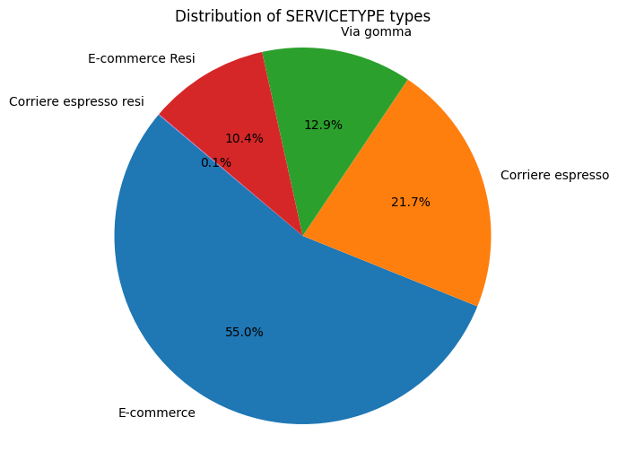

```python
# Create the pie chart
plt.figure(figsize=(8, 6))
plt.pie(conteggio_service_type, labels=conteggio_service_type.index, autopct='%1.1f%%', startangle=140)
plt.title('Distribution of SERVICETYPE types')
plt.axis('equal')  # To maintain the circular shape
plt.show()
```

We count the amount of times a zipcode appears and then we calculate the percentage of each zipcode. After this we filter the zipcode with a 2 or less percent of appearence and group them under the "others" definition

```python
# Count how many times each zip code appears in the 'DEPARTURE_ZIPCODE' column
conteggio_departure_zipcode = df_originale['DEPARTURE_ZIPCODE'].value_counts()

# Calculate the percentage for each zip code
percentuale_zipcode = conteggio_departure_zipcode / conteggio_departure_zipcode.sum() * 100

# Filter zip codes with percentage greater than 2%
zipcodes_frequenti = percentuale_zipcode[percentuale_zipcode > 2]

# Groups all other postcodes into the "Other" category
other = percentuale_zipcode[percentuale_zipcode <= 2].sum()
zipcodes_frequenti['Others'] = other
```

We created a pie graph to rappresent the diffusion of each zipcode in order to understand where was the primary start point

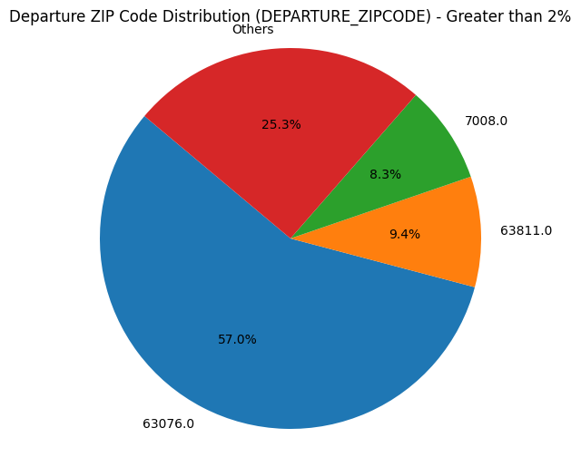

```
Number of different types of vehicles: 6
Types of vehicles present: ['Express' 'Standard' 'Ground' 'Express Next Day' 'Express 2nd Day'
 'Economy Express']
```

```python
# Create the pie chart
plt.figure(figsize=(8, 6))
plt.pie(zipcodes_frequenti, labels=zipcodes_frequenti.index, autopct='%1.1f%%', startangle=140)
plt.title('Departure ZIP Code Distribution (DEPARTURE_ZIPCODE) - Greater than 2%')
plt.axis('equal')  # To maintain the circular shape
plt.show()

df = pd.read_csv('./filtered_delivery_data.csv')

# Find unique types and their count
unique_vehicle_types = df_originale['VEHICLETYPE'].nunique()
all_vehicle_types = df_originale['VEHICLETYPE'].unique()

print(f"Number of different types of vehicles: {unique_vehicle_types}")
print(f"Types of vehicles present: {all_vehicle_types}")
```

## Validation of logistics data

The next code defines a class 'LogisticsDataValidator' that validates logistics data related to vehicle specifications, including weight, volume, distance, time, and shipping dates.

```python
# class definition
class LogisticsDataValidator:
    def __init__(self):
        self.validation_results = []

       # Dictionary of vehicle types with average speeds and capacities
        self.vehicle_specs = {
            'STANDARD': {'max_speed': 90, 'min_speed': 25, 'max_weight': 3500, 'max_volume': 20},
            'EXPRESS': {'max_speed': 100, 'min_speed': 30, 'max_weight': 24000, 'max_volume': 80},
            'GROUND': {'max_speed': 80, 'min_speed': 20, 'max_weight': 40000, 'max_volume': 120},
            'EXPRESS 2ND DAY': {'max_speed': 85, 'min_speed': 25, 'max_weight': 20000, 'max_volume': 60},
            'EXPRESS NEXT DAY': {'max_speed': 90, 'min_speed': 30, 'max_weight': 15000, 'max_volume': 50},
            'ECONOMY EXPRESS': {'max_speed': 70, 'min_speed': 20, 'max_weight': 30000, 'max_volume': 70}
        }
    def check_weights(self, row):
        """Verifica la coerenza tra peso lordo e peso netto."""
        try:
            gross_weight = float(row['GROSS_WEIGHT_KG'])
            net_weight = float(row['NET_WEIGHT_KG'])
            vehicle_type = row['VEHICLETYPE'].upper()

            if gross_weight <= net_weight:
                return False

            if (gross_weight - net_weight) > (net_weight * 0.2):
                return False

            if vehicle_type in self.vehicle_specs:
                if gross_weight > self.vehicle_specs[vehicle_type]['max_weight']:
                    return False

            return True
        except Exception as e:
            self.validation_results.append(f"Errore nel controllo pesi: {str(e)}")
            return False

    def check_volume(self, row):
        """Verifica se il volume è coerente con il tipo di veicolo."""
        try:
            volume = float(row['VOLUME_M3'])
            vehicle_type = row['VEHICLETYPE'].upper()

            if vehicle_type in self.vehicle_specs:
                return 0 < volume <= self.vehicle_specs[vehicle_type]['max_volume']
            return True
        except Exception as e:
            self.validation_results.append(f"Errore nel controllo volume: {str(e)}")
            return False

    def check_distance_time(self, row):
        """Verifica se la distanza è coerente con il tempo di consegna."""
        try:
            distance = float(row['DECLARED_DISTANCE_KM'])
            delivery_time = float(row['DELIVERY_TIME_HH'])
            vehicle_type = row['VEHICLETYPE'].upper()

            if delivery_time == 0:
                return False

            speed = distance / delivery_time

            if vehicle_type in self.vehicle_specs:
                min_speed = self.vehicle_specs[vehicle_type]['min_speed']
                max_speed = self.vehicle_specs[vehicle_type]['max_speed']
                return min_speed <= speed <= max_speed

            return True
        except Exception as e:
            self.validation_results.append(f"Errore nel controllo distanza/tempo: {str(e)}")
            return False

    def check_dates(self, row):
        """Verifica la coerenza tra data di spedizione e data di consegna effettiva."""
        try:
            shipping_date = pd.to_datetime(row['SHIPPING_DATE'])
            delivery_date = pd.to_datetime(row['ACTUAL_DELIVERY_DATE'])

            if delivery_date < shipping_date:
                return False

            if delivery_date.weekday() != int(row['WDAY']):
                return False

            return True
        except Exception as e:
            self.validation_results.append(f"Errore nel controllo date: {str(e)}")
            return False

    def validate_row(self, row):
        """Valida tutti gli aspetti di una singola riga."""
        return {
            'pesi_ok': self.check_weights(row),
            'volume_ok': self.check_volume(row),
            'distanza_tempo_ok': self.check_distance_time(row),
            'date_ok': self.check_dates(row)
        }
```

```python
# read csv
df = pd.read_csv('./Definitivo1.csv')

# Create validator instance
validator = LogisticsDataValidator()

# Validate the data
validation_results = []
for index, row in df.iterrows():
    row_results = validator.validate_row(row)
    row_results['riga'] = index + 1
    validation_results.append(row_results)


# Create DataFrame with results
results_df = pd.DataFrame(validation_results)

# Add column for overall result
results_df['tutti_controlli_ok'] = results_df.drop('riga', axis=1).all(axis=1)

# View results
print("\nRisultati della validazione:")
display(results_df)

# Calculate and print statistics
total_rows = len(results_df)
valid_rows = results_df['tutti_controlli_ok'].sum()
print(f"\nStatistiche:")
print(f"Righe totali: {total_rows}")
print(f"Righe valide: {valid_rows}")
print(f"Percentuale valida: {(valid_rows/total_rows*100):.2f}%")
```

```
Risultati della validazione:
```

|  | pesi_ok | volume_ok | distanza_tempo_ok | date_ok | riga | tutti_controlli_ok |
| --- | --- | --- | --- | --- | --- | --- |
| 0 | True | False | False | True | 1 | False |
| 1 | False | False | False | True | 2 | False |
| 2 | False | False | False | True | 3 | False |
| 3 | False | False | False | True | 4 | False |
| 4 | False | False | False | True | 5 | False |
| ... | ... | ... | ... | ... | ... | ... |
| 14549 | False | True | False | False | 14550 | False |
| 14550 | False | False | False | False | 14551 | False |
| 14551 | False | False | False | False | 14552 | False |
| 14552 | False | False | False | False | 14553 | False |
| 14553 | False | False | False | True | 14554 | False |

14554 rows × 6 columns

```
Statistiche:
Righe totali: 14554
Righe valide: 18
Percentuale valida: 0.12%
```